# Predicting heart disease with classification trees

Ryan LeBon

4/23/2018

In this report, I will be trying to predict heart disease using classification trees. This data set was donated on 1988-07-01 by David W. Aha and is used by [UC Irvine](https://archive.ics.uci.edu/ml/datasets/Heart+Disease) as a machine learning repository. There are also many relevent papers that cite this data set as well, which are located on the link above. The names and social security numbers of the patients were removed from the database, and replaced with dummy values.

```r
> library(rpart)
> library(rpart.plot)
> library(maptree)
Loading required package: cluster
> # the following utility files can be found attached to the assignment
> source("https://raw.githubusercontent.com/grbruns/cst383/master/lin-regr-util.R")
> source("https://raw.githubusercontent.com/grbruns/cst383/master/class-util.R")
```

### Reading and preprocessing the data

```r
> heart = read.table("https://raw.githubusercontent.com/grbruns/cst383/master/heart.dat", quote = "/")
> names(heart) <- c("AGE", "SEX", "CHESTPAIN", "RESTBP", "CHOL",
+                   "SUGAR", "ECG", "MAXHR", "ANGINA", "DEP", "EXERCISE", "FLUOR",
+                   "THAL", "OUTPUT")
> names(heart) = tolower(names(heart))
>
> # convert output to factor
> heart$output = factor(heart$output)
```

### Data exploration

In this data exploration we will look at the features that are categorical which pertain to the subjects who were being tested for heart disease. There are 270 rows in this data set. I created some barplots,boxplots, and plots, of the main features in order to analyze what was going on during this study. Please look at the summary below to see the types of features in the dataset.

```r
> summary(heart)
```

```
      age             sex           chestpain         restbp
 Min.   :29.00   Min.   :0.0000   Min.   :1.000   Min.   : 94.0
 1st Qu.:48.00   1st Qu.:0.0000   1st Qu.:3.000   1st Qu.:120.0
 Median :55.00   Median :1.0000   Median :3.000   Median :130.0
 Mean   :54.43   Mean   :0.6778   Mean   :3.174   Mean   :131.3
 3rd Qu.:61.00   3rd Qu.:1.0000   3rd Qu.:4.000   3rd Qu.:140.0
 Max.   :77.00   Max.   :1.0000   Max.   :4.000   Max.   :200.0
      chol           sugar             ecg            maxhr
 Min.   :126.0   Min.   :0.0000   Min.   :0.000   Min.   : 71.0
 1st Qu.:213.0   1st Qu.:0.0000   1st Qu.:0.000   1st Qu.:133.0
 Median :245.0   Median :0.0000   Median :2.000   Median :153.5
 Mean   :249.7   Mean   :0.1481   Mean   :1.022   Mean   :149.7
 3rd Qu.:280.0   3rd Qu.:0.0000   3rd Qu.:2.000   3rd Qu.:166.0
 Max.   :564.0   Max.   :1.0000   Max.   :2.000   Max.   :202.0
     angina            dep          exercise         fluor
 Min.   :0.0000   Min.   :0.00   Min.   :1.000   Min.   :0.0000
 1st Qu.:0.0000   1st Qu.:0.00   1st Qu.:1.000   1st Qu.:0.0000
 Median :0.0000   Median :0.80   Median :2.000   Median :0.0000
 Mean   :0.3296   Mean   :1.05   Mean   :1.585   Mean   :0.6704
 3rd Qu.:1.0000   3rd Qu.:1.60   3rd Qu.:2.000   3rd Qu.:1.0000
 Max.   :1.0000   Max.   :6.20   Max.   :3.000   Max.   :3.0000
      thal       output
 Min.   :3.000   1:150
 1st Qu.:3.000   2:120
 Median :3.000
 Mean   :4.696
 3rd Qu.:7.000
 Max.   :7.000
```

```r
> str(heart)
```

```
'data.frame':   270 obs. of  14 variables:
 $ age      : num  70 67 57 64 74 65 56 59 60 63 ...
 $ sex      : num  1 0 1 1 0 1 1 1 1 0 ...
 $ chestpain: num  4 3 2 4 2 4 3 4 4 4 ...
 $ restbp   : num  130 115 124 128 120 120 130 110 140 150 ...
 $ chol     : num  322 564 261 263 269 177 256 239 293 407 ...
 $ sugar    : num  0 0 0 0 0 0 1 0 0 0 ...
 $ ecg      : num  2 2 0 0 2 0 2 2 2 2 ...
 $ maxhr    : num  109 160 141 105 121 140 142 142 170 154 ...
 $ angina   : num  0 0 0 1 1 0 1 1 0 0 ...
 $ dep      : num  2.4 1.6 0.3 0.2 0.2 0.4 0.6 1.2 1.2 4 ...
 $ exercise : num  2 2 1 2 1 1 2 2 2 2 ...
 $ fluor    : num  3 0 0 1 1 0 1 1 2 3 ...
 $ thal     : num  3 7 7 7 3 7 6 7 7 7 ...
 $ output   : Factor w/ 2 levels "1","2": 2 1 2 1 1 1 2 2 2 2 ...
```

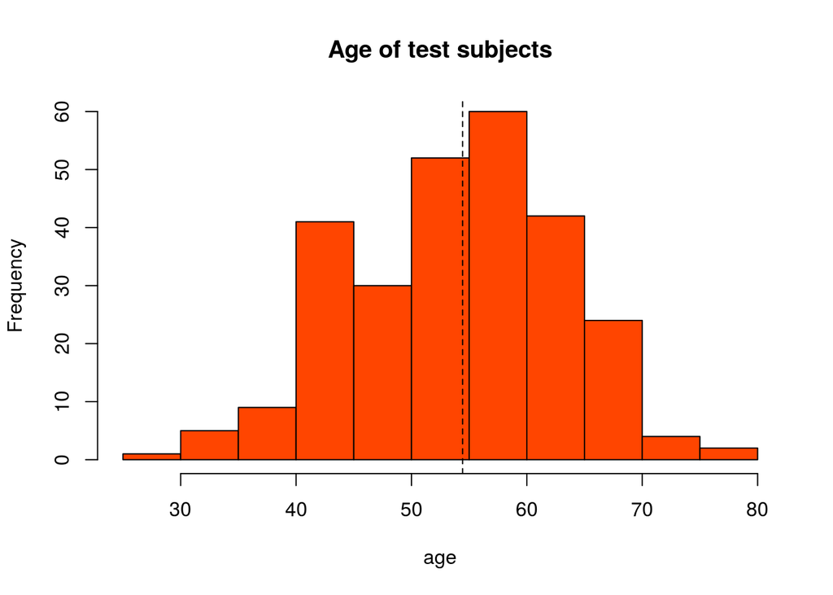

```r
> hist(heart$age,main="Age of test subjects",col="orangered",xlab="age",xlim=c(25,80))
> abline(v=mean(heart$age),lty=2)
```

In this barplot you can clearly see that there are more men then women in this study. There are exactly 183 males and 87 females.

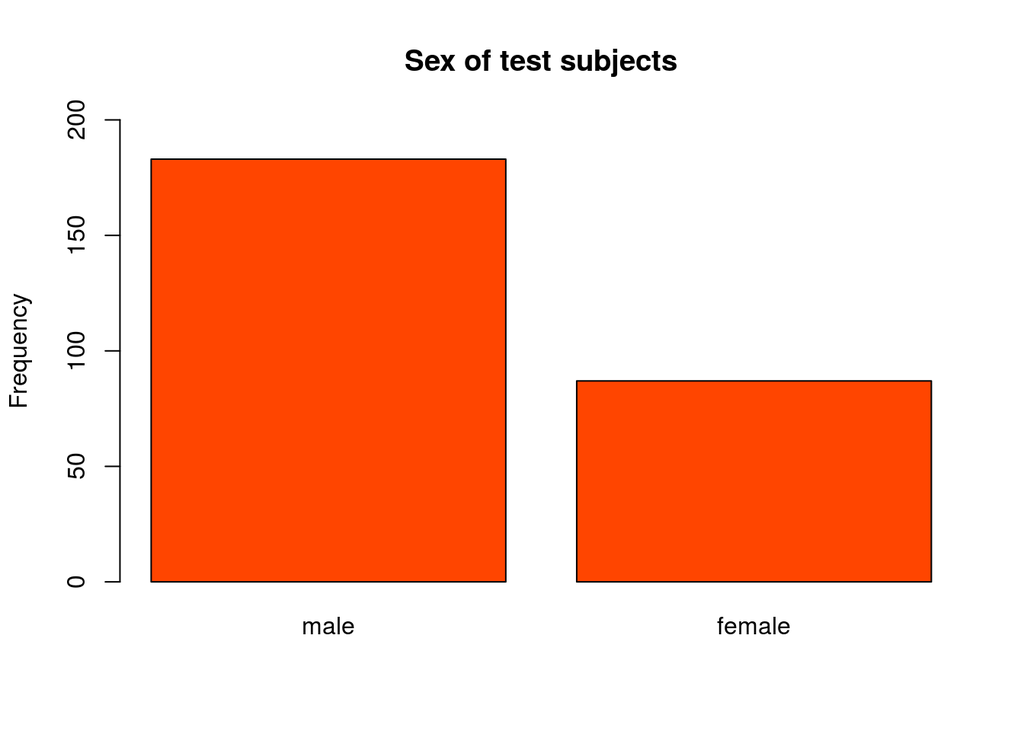

```r
> barplot(sort(table(heart$sex),decreasing = T),main="Sex of test subjects",ylab="Frequency",col="orangered",beside=T,names.arg=c("male","female"),ylim=c(0,200))
```

This barplot represents the levels of chest pain that the subjects were experiencing. The levels go from typical angina being ‘high chest pain’ to asymptomatic being ‘no chest pain’. According to google, “Angina often is described as pressure, squeezing, burning, or tightness in the chest. The pain or discomfort usually starts behind the breastbone. Pain from angina also can occur in the arms, shoulders, neck, jaw, throat, or back. The pain may feel like indigestion.”

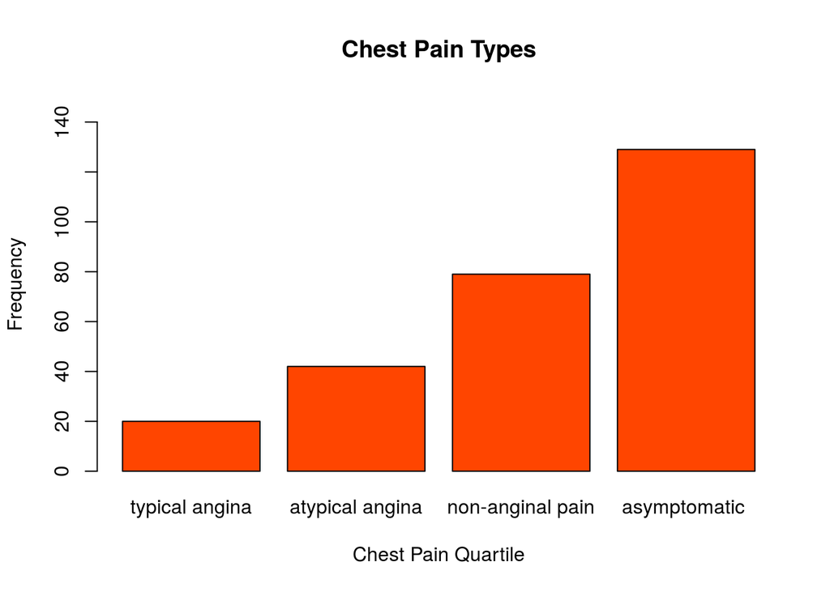

```r
> barplot(table(heart$chestpain),main="Chest Pain Types",xlab="Chest Pain Quartile",ylim=c(0,150),col=c("orangered"),ylab="Frequency",names.arg=c("typical angina","atypical angina","non-anginal pain","asymptomatic "))
```

This is a boxplot, it is similar to the barplot above except it compares chest pain with ages. The median age is represented by the black bar inside of the orange boxes.

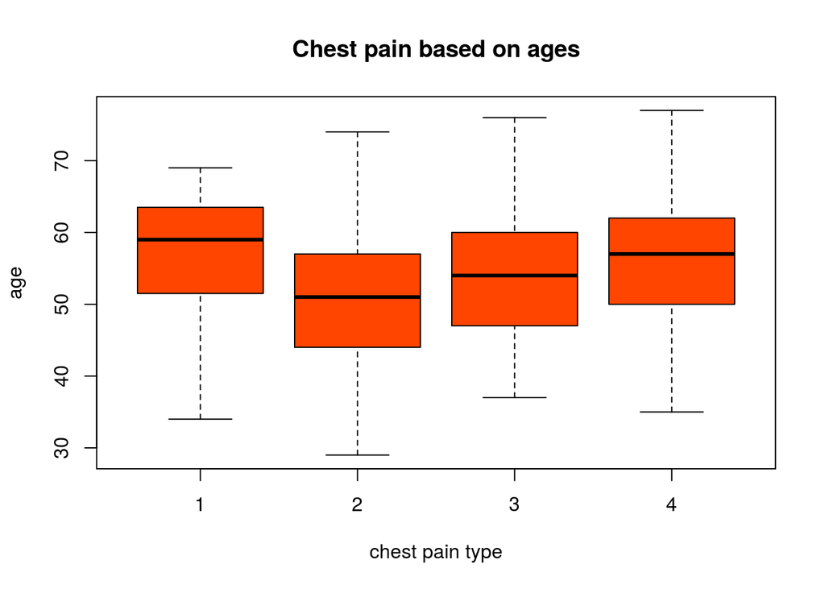

```r
> symptoms <- c("typical angina","atypical angina","non-anginal pain","asymptomatic ")
> boxplot(age~chestpain,pch=8,col="orangered",data=heart,ylab="age",xlab="chest pain type",main="Chest pain based on ages")
```

```r
> for(i in 1:4)
+   cat(sprintf("For the symptom %s at the index [%i] there were a total of  %i test subjects. \n",symptoms[i],i,length(heart$chestpain[heart$chestpain==i])))
```

```
For the symptom typical angina at the index [1] there were a total of  20 test subjects.
For the symptom atypical angina at the index [2] there were a total of  42 test subjects.
For the symptom non-anginal pain at the index [3] there were a total of  79 test subjects.
For the symptom asymptomatic  at the index [4] there were a total of  129 test subjects.
```

This is a plot of ages and resting blood pressure, were the orange stars represent having heart disease and the blue stars represent having no heart disease.

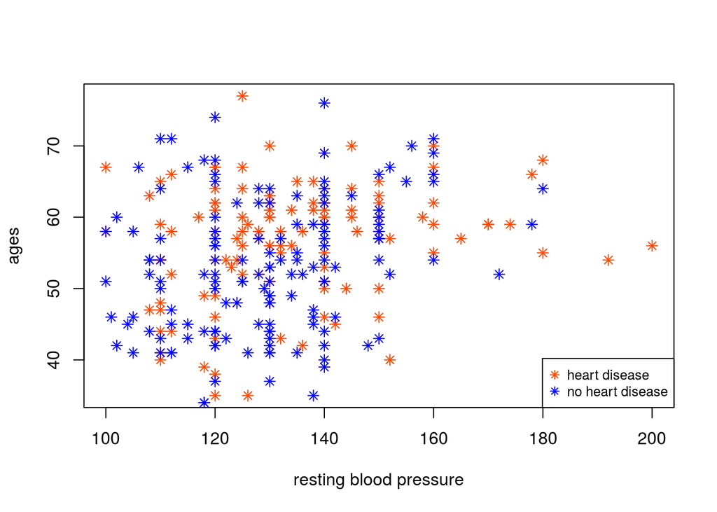

```r
> plot(age[output==2]~restbp[output==2],data=heart,pch=8,col=c("orangered"),xlab="resting blood pressure",ylab="ages")
> points(age[output==1]~restbp[output==1],data=heart,pch=8,col=c("blue"))
> legend("bottomright",legend=c("heart disease","no heart disease"),col=c("orangered","blue"),pch=8, cex=0.8)
```

This is a plot of ages and max heart rate, were the orange stars represent having heart disease and the blue stars represent having no heart disease.

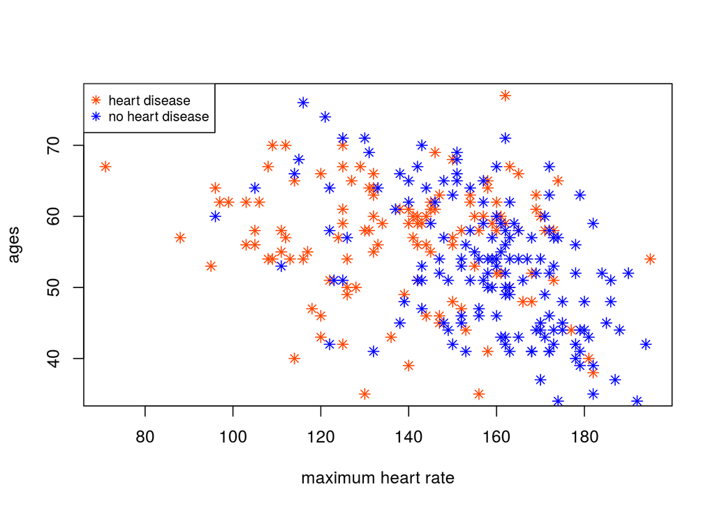

```r
> plot(age[output==2]~maxhr[output==2],data=heart,pch=8,col=c("orangered"),xlab="maximum heart rate",ylab="ages")
> points(age[output==1]~maxhr[output==1],data=heart,pch=8,col=c("blue"))
> legend("topleft",legend=c("heart disease","no heart disease"),col=c("orangered","blue"),pch=8, cex=0.8)
```

This is a plot of resting blood pressure and max heart rate, were the orange stars represent having heart disease and the blue stars represent having no heart disease.

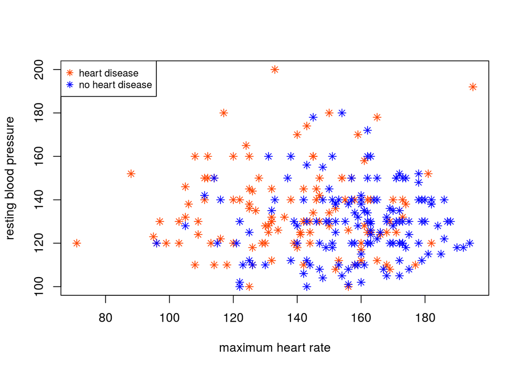

```r
> plot(restbp[output==2]~maxhr[output==2],pch=8,col="orangered",data=heart,xlab="maximum heart rate",ylab="resting blood pressure")
> points(restbp[output==1]~maxhr[output==1],pch=8,col="blue",data=heart)
> legend("topleft",legend=c("heart disease","no heart disease"),col=c("orangered","blue"),pch=8, cex=0.8)
```

### Building a classification tree

This is the first classification tree that I built using all of the features on the training data set. The training data has a higher sample than the test data set so the predictions will be more accurate than the testing data set. The green nodes indicate having no heart disease while the pink nodes indicate having heart disease. If you take a look at the summary, we can see that the most important features in the training data set include; ‘chest pain’, ‘thal’, ‘fluor’, ‘maxhr’ and so on…

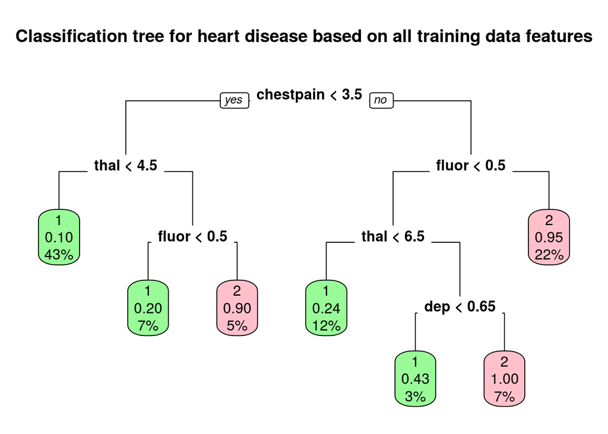

```r
> # training and test sets
> set.seed(132)
> split = split_data(heart)
> tr_dat = split[[1]]
> te_dat = split[[2]]
>
> first_fit <- rpart(output~.,data=tr_dat,method="class")
> prp(first_fit, extra="auto", varlen=-10,
+     main="Classification tree for heart disease based on all training data features",
+     box.col=c("palegreen", "pink")[first_fit$frame$yval],branch=1)
```

```r
> summary(first_fit)
```

```
Call:
rpart(formula = output ~ ., data = tr_dat, method = "class")
  n= 201

          CP nsplit rel error    xerror       xstd
1 0.46511628      0 1.0000000 1.0000000 0.08156459
2 0.07558140      1 0.5348837 0.6976744 0.07543775
3 0.04651163      3 0.3837209 0.5930233 0.07173552
4 0.01162791      5 0.2906977 0.4302326 0.06388903
5 0.01000000      6 0.2790698 0.4418605 0.06454894

Variable importance
chestpain      thal     fluor     maxhr    angina       dep       age
       23        19        15        12        11        10         4
   restbp       sex      chol  exercise
        2         2         2         1

Node number 1: 201 observations,    complexity param=0.4651163
  predicted class=1  expected loss=0.4278607  P(node) =1
    class counts:   115    86
   probabilities: 0.572 0.428
  left son=2 (111 obs) right son=3 (90 obs)
  Primary splits:
      chestpain < 3.5   to the left,  improve=28.24280, (0 missing)
      thal      < 4.5   to the left,  improve=27.58151, (0 missing)
      fluor     < 0.5   to the left,  improve=20.47939, (0 missing)
      maxhr     < 147.5 to the right, improve=16.93352, (0 missing)
      angina    < 0.5   to the left,  improve=16.74484, (0 missing)
  Surrogate splits:
      angina < 0.5   to the left,  agree=0.736, adj=0.411, (0 split)
      thal   < 4.5   to the left,  agree=0.701, adj=0.333, (0 split)
      maxhr  < 147.5 to the right, agree=0.687, adj=0.300, (0 split)
      fluor  < 1.5   to the left,  agree=0.622, adj=0.156, (0 split)
      dep    < 1.85  to the left,  agree=0.617, adj=0.144, (0 split)

Node number 2: 111 observations,    complexity param=0.04651163
  predicted class=1  expected loss=0.1891892  P(node) =0.5522388
    class counts:    90    21
   probabilities: 0.811 0.189
  left son=4 (86 obs) right son=5 (25 obs)
```

[output cut: 99 more lines]

```
      restbp   < 143   to the left,  improve=0.7619048, (0 missing)
  Surrogate splits:
      maxhr    < 151   to the right, agree=0.857, adj=0.571, (0 split)
      exercise < 1.5   to the left,  agree=0.762, adj=0.286, (0 split)
      angina   < 0.5   to the left,  agree=0.714, adj=0.143, (0 split)

Node number 26: 7 observations
  predicted class=1  expected loss=0.4285714  P(node) =0.03482587
    class counts:     4     3
   probabilities: 0.571 0.429

Node number 27: 14 observations
  predicted class=2  expected loss=0  P(node) =0.06965174
    class counts:     0    14
   probabilities: 0.000 1.000
```

Here are the predictions based off of the first classification tree.

```r
> prediction <- predict(first_fit,te_dat,type="class")
> actuals = te_dat$output
> table(actuals, prediction)
```

```
       prediction
actuals  1  2
      1 29  6
      2  6 28
```

```r
> mean(actuals == prediction)
```

```
[1] 0.826087
```

### Classifying test data

The green nodes indicate having no heart disease while the pink nodes indicate having heart disease. On the first two tree’s I fitted the data to the testing data. On tree’s three and four I fitted the models to the training data.

#### First Classification Tree

This tree was fitted to the features: ‘chestpain’,‘thal’, and ‘fluor’.

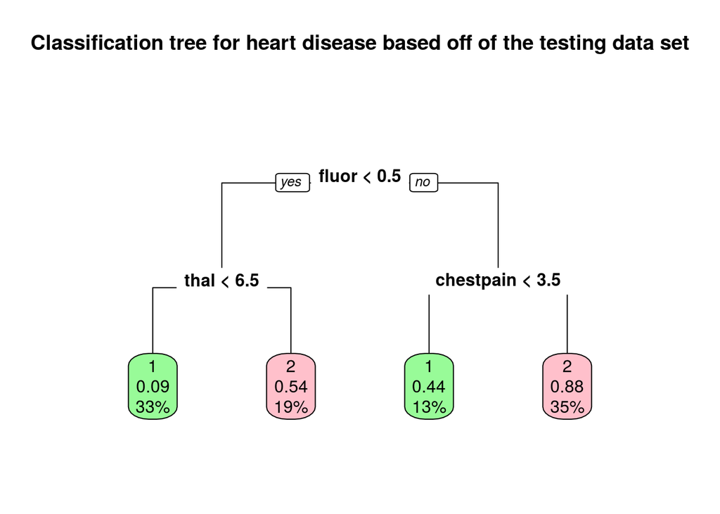

```r
> fit <- rpart(output~chestpain+thal+fluor,data=te_dat,method="class")
> prp(fit, extra="auto", varlen=-10,
+     main="Classification tree for heart disease based off of the testing data set",
+     box.col=c("palegreen", "pink")[fit$frame$yval],branch=1)
```

#### Second Classification Tree

This tree was fitted to the features: ‘chol’ and ‘age’.

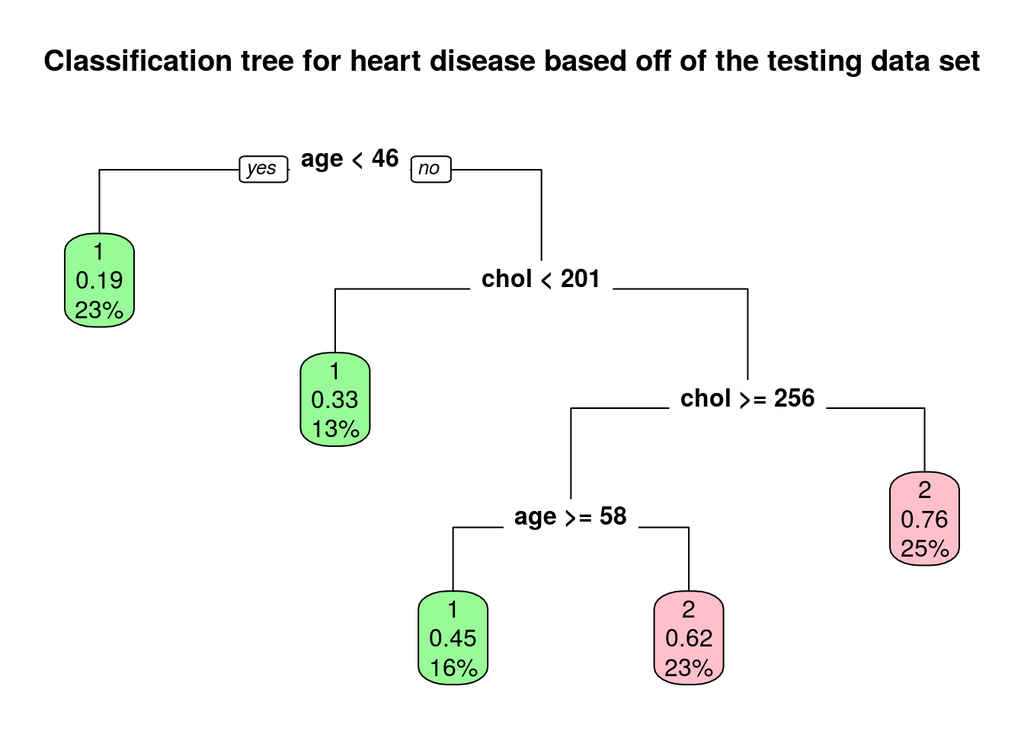

```r
> fit3 <- rpart(output~chol+age,data=te_dat,method="class")
> prp(fit3, extra="auto", varlen=-10,
+     main="Classification tree for heart disease based off of the testing data set",
+     box.col=c("palegreen", "pink")[fit3$frame$yval],branch=1)
```

#### Third Classification Tree

This tree was fitted to the features: ‘chestpain’,‘thal’, and ‘fluor’.

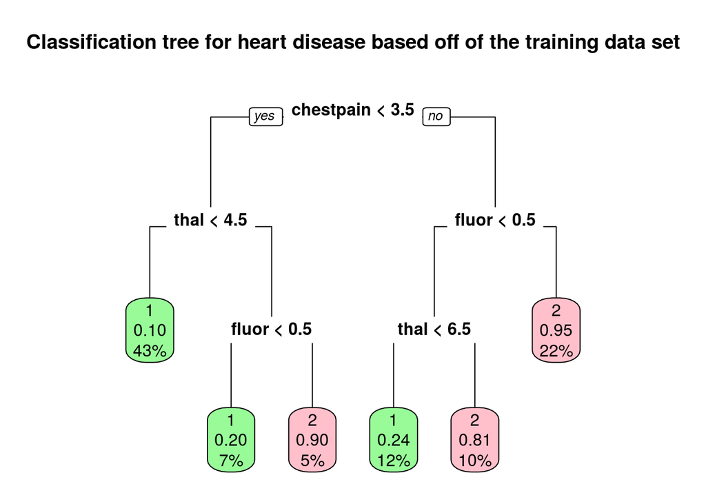

```r
> fit2 <- rpart(output~chestpain+thal+fluor,data=tr_dat,method="class")
> prp(fit2, extra="auto", varlen=-10,
+     main="Classification tree for heart disease based off of the training data set",
+     box.col=c("palegreen", "pink")[fit2$frame$yval],branch=1)
```

#### Fourth Classification Tree

This tree was fitted to the features: ‘chol’ and ‘age’.

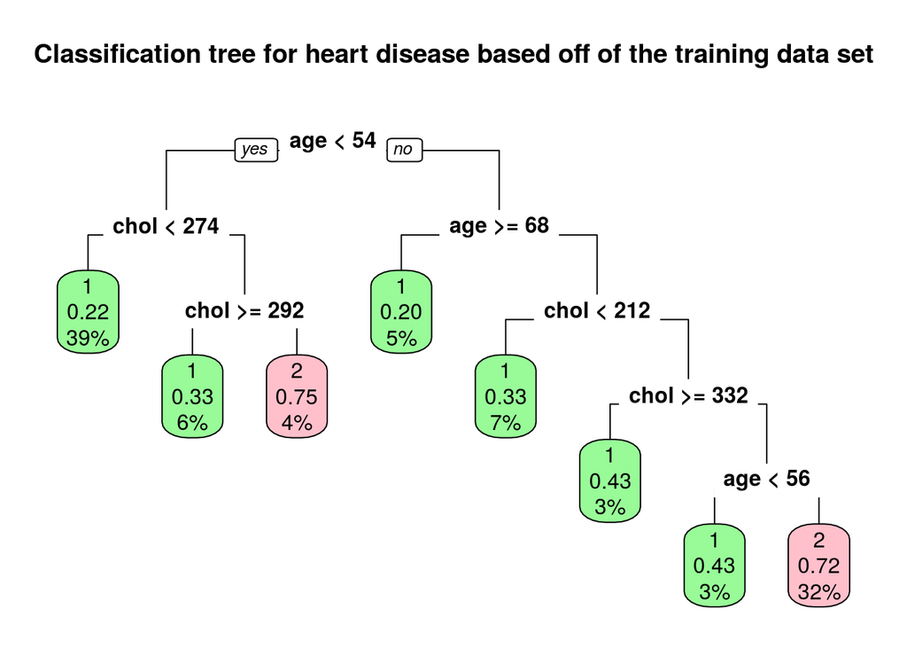

```r
> fit4 <- rpart(output~chol+age,data=tr_dat,method="class")
> prp(fit4, extra="auto", varlen=-10,
+     main="Classification tree for heart disease based off of the training data set",
+     box.col=c("palegreen", "pink")[fit4$frame$yval],branch=1)
```

### Assessing the model

Here are the confusion matrices and the accuracy of the classification trees that are listed above.

#### First Classification Tree Confusion Matrix and Accuracy

```r
> predicted = predict(fit, te_dat, type="class")
> actual = te_dat$output
> table(actual, predicted)
```

```
      predicted
actual  1  2
     1 26  9
     2  6 28
```

```r
> mean(actual == predicted)
```

```
[1] 0.7826087
```

#### Second Classification Tree Confusion Matrix and Accuracy

```r
> predicted3 <- predict(fit3,te_dat,type="class")
> actual3 <- te_dat$output
> table(actual3,predicted3)
```

```
       predicted3
actual3  1  2
      1 25 10
      2 11 23
```

```r
> mean(actual3==predicted3)
```

```
[1] 0.6956522
```

#### Third Classification Tree Confusion Matrix and Accuracy

```r
> predicted2 <- predict(fit2,tr_dat,type="class")
> actual2 <- tr_dat$output
> table(actual2,predicted2)
```

```
       predicted2
actual2   1   2
      1 108   7
      2  18  68
```

```r
> mean(actual2==predicted2)
```

```
[1] 0.8756219
```

#### Fourth Classification Tree Confusion Matrix and Accuracy

```r
> predicted4 <- predict(fit4,tr_dat,type="class")
> actual4 <- tr_dat$output
> table(actual4,predicted4)
```

```
       predicted4
actual4  1  2
      1 95 20
      2 34 52
```

```r
> mean(actual4==predicted4)
```

```
[1] 0.7313433
```

#### Learning Curve

This is a learning curve that shows use the test error rate and the training size of the data. The training size is the number of rows that are located inside of the training dataset. This is good to see because the learning curve is very useful in data science. It helps in observing whether our model is having the high bias or high variance problem. The X-Axis is the number of samples (training set size) and the Y-Axis is the Error Rate ((RSS/J(theta)/cost function )). The learning curve is fitted to all of the features.

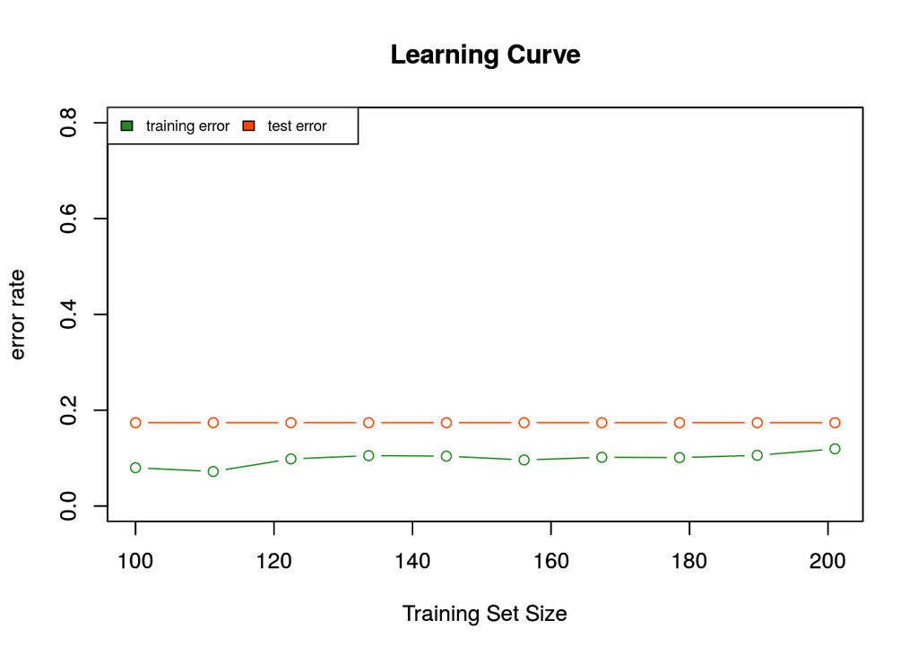

```r
> create_learning_curve <- function(){
+
+   te_errs = c()
+
+   tr_errs = c()
+
+   te_actual = te_dat$output
+
+   tr_sizes = seq(100, nrow(tr_dat), length.out=10)
+
+   for (tr_size in tr_sizes) {
+
+     tr_dat1 = tr_dat[1:tr_size,]
+
+     tr_actual = tr_dat1$output
+
+
+     fit = rpart(output~. , method = "class" , data = tr_dat)
+
+     # error on training set
+
+     tr_predicted = predict(fit, tr_dat1, type="class")
+
+     err = mean(tr_actual != tr_predicted)
+
+     tr_errs = c(tr_errs, err)
+
+
+
+     # error on test set
+
+     te_predicted = predict(fit, te_dat, type="class")
+
+     err = mean(te_actual != te_predicted)
+
+     te_errs = c(te_errs, err)
+
+   }
+
+   plot(tr_sizes , tr_errs   ,type = "b" , ylim = c(0, 0.8) , ylab = "error rate", xlab="Training Set Size", col = "forestgreen",main="Learning Curve")
+   par(new = TRUE)
+   plot(tr_sizes , te_errs   ,type = "b" ,ylim = c(0 , 0.8), ylab = "error rate" , xlab="Training Set Size", col = "orangered",main="Learning Curve")
+
+   legend("topleft",c("training error","test error"),fill=c("forestgreen","orangered"),horiz=TRUE,cex=0.7)
+   }
>
> create_learning_curve()
```